# INFO659: Project on Rainfall Forcasting

#### Project Team 4

1. Suresh Athanti - SA3663
2. Jeevan reddy Geereddy - JG3687
3. Karthikreddy Kuna - KK3375

### Introduction:

Rainfall prediction remains a serious concern and has attracted the attention of governments, industries, risk management entities and scientiﬁc community. Rainfall is a climatic factor that aﬀects many human activities like agricultural production, construction, power generation, forestry and tourism, among others.

Weather forecasting is done to predict to weather conditions in future time. The climatic conditions are based on the factors like wind speed, directions, humidity, temperature and locations. Forecasts of meteorological time series can help decision-making processes carried out by organizations responsible of disaster prevention. Therefore, having an appropriate approach for rainfall prediction makes it possible to take preventive and mitigation measures for these natural phenomena.

### Problem Statement:

The objective of this project is to predict the rainfall in Australia based on the factors like wind speed, directions, humidity, temperature and locations. It is mainly focused on the development of models for rainfall prediction of Australia daily basis.

### Attribute description in the Dataset:

–>Dataset had different types of data attributes whose columns description is as below:

Date - Date of observation.  
Location -Name of the location of the weather station.  
MinTemp - Minimum temperature in degrees celsius.  
MaxTemp - Maximum temperature in degrees celsius.  
Rainfall - Amount of rainfall recorded for the day in mm.  
Evaporation - The so-called Class A pan evaporation (mm) in the 24 hours to 9am.  
Sunshine - Number of hours of bright sunshine on the single day.  
WindGustDir - Direction of the strongest wind gust in the 24 hours.  
WindGustSpeed - Speed (km/h) of the strongest wind gust in the 24 hours.  
WindDir9am - Direction of the wind at 9am.  
WindDir3pm - Direction of the wind at 3pm.  
WindSpeed9am - Wind speed (km/hr) averaged over 10 minutes prior to 9am.  
WindSpeed3pm - Wind speed (km/hr) averaged over 10 minutes prior to 3pm.  
Humidity9am - Humidity (percent) at 9am.  
Humidity3pm -Humidity (percent) at 3pm.  
Pressure9am - Atmospheric pressure (hpa) reduced to mean sea level at 9am.  
Pressure3pm - Atmospheric pressure (hpa) reduced to mean sea level at 3pm.  
Cloud9am - Fraction of sky obscured by cloud at 9am. This is measured in “oktas”, which are a unit of eigths. It records how many eigths of the sky are obscured by cloud. A 0 measure indicates completely clear sky whilst an 8 indicates that it is completely overcast.  
Cloud3pm -Fraction of sky obscured by cloud (in “oktas”: eighths) at 3pm. See Cload9am for a description of the values.  
Temp9am - Temperature (degrees C) at 9am.  
Temp3pm - Temperature (degrees C) at 3pm.  
RainToday - Boolean 1 if precipitation (mm) in the 24 hours to 9am exceeds 1mm, otherwise 0  
RISK_MM - Amount of next day rain in mm. Used to create response variable RainTomorrow. A kind of measure of the “risk”.  
RainTomorrow - Target variable to predict tomorrows rain.

### Data Preparation:

–> Initially, all the required libraries to perform our analysis was loaded into the project.

```r
library(ggplot2)
library(rpart.plot)
library(cowplot)
library(ROCR)
library(dplyr)
library(caTools)
library(plyr)
library(corrplot)
library(caret)
library(caretEnsemble)
```

### Importing the dataset:

–> We have imported the original dataset and the format of the same was CSV. In the next step we are finding the class of each attribute in the dataset.

```r
weather_data <- read.csv("weatherAUS.csv")
```

```r
str(weather_data)
```

```
'data.frame':   142193 obs. of  24 variables:
 $ Date         : Factor w/ 3436 levels "2007-11-01","2007-11-02",..: 397 398 399 400 401 402 403 404 405 406 ...
 $ Location     : Factor w/ 49 levels "Adelaide","Albany",..: 3 3 3 3 3 3 3 3 3 3 ...
 $ MinTemp      : num  13.4 7.4 12.9 9.2 17.5 14.6 14.3 7.7 9.7 13.1 ...
 $ MaxTemp      : num  22.9 25.1 25.7 28 32.3 29.7 25 26.7 31.9 30.1 ...
 $ Rainfall     : num  0.6 0 0 0 1 0.2 0 0 0 1.4 ...
 $ Evaporation  : num  NA NA NA NA NA NA NA NA NA NA ...
 $ Sunshine     : num  NA NA NA NA NA NA NA NA NA NA ...
 $ WindGustDir  : Factor w/ 16 levels "E","ENE","ESE",..: 14 15 16 5 14 15 14 14 7 14 ...
 $ WindGustSpeed: int  44 44 46 24 41 56 50 35 80 28 ...
 $ WindDir9am   : Factor w/ 16 levels "E","ENE","ESE",..: 14 7 14 10 2 14 13 11 10 9 ...
 $ WindDir3pm   : Factor w/ 16 levels "E","ENE","ESE",..: 15 16 16 1 8 14 14 14 8 11 ...
 $ WindSpeed9am : int  20 4 19 11 7 19 20 6 7 15 ...
 $ WindSpeed3pm : int  24 22 26 9 20 24 24 17 28 11 ...
 $ Humidity9am  : int  71 44 38 45 82 55 49 48 42 58 ...
 $ Humidity3pm  : int  22 25 30 16 33 23 19 19 9 27 ...
 $ Pressure9am  : num  1008 1011 1008 1018 1011 ...
 $ Pressure3pm  : num  1007 1008 1009 1013 1006 ...
 $ Cloud9am     : int  8 NA NA NA 7 NA 1 NA NA NA ...
 $ Cloud3pm     : int  NA NA 2 NA 8 NA NA NA NA NA ...
 $ Temp9am      : num  16.9 17.2 21 18.1 17.8 20.6 18.1 16.3 18.3 20.1 ...
 $ Temp3pm      : num  21.8 24.3 23.2 26.5 29.7 28.9 24.6 25.5 30.2 28.2 ...
 $ RainToday    : Factor w/ 2 levels "No","Yes": 1 1 1 1 1 1 1 1 1 2 ...
 $ RISK_MM      : num  0 0 0 1 0.2 0 0 0 1.4 0 ...
 $ RainTomorrow : Factor w/ 2 levels "No","Yes": 1 1 1 1 1 1 1 1 2 1 ...
```

–> Based on below relation, it is observed that RiskMM is equalent to the Rain Tomorrow.

```r
all.equal(weather_data$RISK_MM > 1, weather_data$RainTomorrow == "Yes")
```

```
[1] TRUE
```

```r
all.equal(weather_data$Rainfall > 1, weather_data$RainToday == "Yes")
```

```
[1] TRUE
```

### Cleaning the Data

–> Here, we are checking for the incomplete fields(NA) in the data and the results are printed as per coloumn.

```r
cols_withNa <- apply(weather_data, 2, function(x) sum(is.na(x)))

cols_withNa
```

```
         Date      Location       MinTemp       MaxTemp      Rainfall
            0             0           637           322          1406
  Evaporation      Sunshine   WindGustDir WindGustSpeed    WindDir9am
        60843         67816          9330          9270         10013
   WindDir3pm  WindSpeed9am  WindSpeed3pm   Humidity9am   Humidity3pm
         3778          1348          2630          1774          3610
  Pressure9am   Pressure3pm      Cloud9am      Cloud3pm       Temp9am
        14014         13981         53657         57094           904
      Temp3pm     RainToday       RISK_MM  RainTomorrow
         2726          1406             0             0
```

–> We have identified the potential required fields in the dataset and the remaining fields which are not suitable or improperly formatted for the analysis are omitted.

–>Below are the various attributes which are dropped from the data set for further analysis. Date, Evaporation, Sunshine, Cloud9am, Cloud3pm, RISK_MM, Location, WindGustDir, WindDir9am, WindDir3pm.

```r
weather_data$Date<-NULL
weather_data$Evaporation<-NULL
weather_data$Sunshine<-NULL
weather_data$Cloud9am<-NULL
weather_data$Cloud3pm<-NULL
weather_data$RISK_MM<-NULL
weather_data$Location<-NULL
weather_data$WindGustDir<-NULL
weather_data$WindDir9am<-NULL
weather_data$WindDir3pm<-NULL
```

–>After removing the attributes which are no longer required for analysis, we have cleaned the data which contains NA values.

–>Below are the attributes which are considered for further analysis. MinTemp,MaxTemp,WindGustSpeed,Humidity,Rainfall

```r
weather_data$MinTemp <- c(weather_data$MinTemp[2:nrow(weather_data)], NA)
weather_data$MaxTemp <- c(weather_data$MaxTemp[2:nrow(weather_data)], NA)
weather_data$WindGustSpeed <- c(weather_data$WindGustSpeed[2:nrow(weather_data)], NA)
weather_data$Humidity3pm <- c(weather_data$Humidity3pm[2:nrow(weather_data)], NA)
weather_data$Rainfall <- c(weather_data$Rainfall[2:nrow(weather_data)], NA)
```

–>The below data represents the effective attributes which contains clean data and are apt for performing analysis.

```r
weather_data1 = weather_data[complete.cases(weather_data),]
head(weather_data1)
```

|  | MinTemp | MaxTemp | Rainfall | WindGustSpeed | WindSpeed9am | WindSpeed3pm | Humidity9am | Humidity3pm | Pressure9am | Pressure3pm | Temp9am | Temp3pm | RainToday | RainTomorrow |
| --- | --- | --- | --- | --- | --- | --- | --- | --- | --- | --- | --- | --- | --- | --- |
| 1 | 7.4 | 25.1 | 0.0 | 44 | 20 | 24 | 71 | 25 | 1007.7 | 1007.1 | 16.9 | 21.8 | No | No |
| 2 | 12.9 | 25.7 | 0.0 | 46 | 4 | 22 | 44 | 30 | 1010.6 | 1007.8 | 17.2 | 24.3 | No | No |
| 3 | 9.2 | 28.0 | 0.0 | 24 | 19 | 26 | 38 | 16 | 1007.6 | 1008.7 | 21.0 | 23.2 | No | No |
| 4 | 17.5 | 32.3 | 1.0 | 41 | 11 | 9 | 45 | 33 | 1017.6 | 1012.8 | 18.1 | 26.5 | No | No |
| 5 | 14.6 | 29.7 | 0.2 | 56 | 7 | 20 | 82 | 23 | 1010.8 | 1006.0 | 17.8 | 29.7 | No | No |
| 6 | 14.3 | 25.0 | 0.0 | 50 | 19 | 24 | 55 | 19 | 1009.2 | 1005.4 | 20.6 | 28.9 | No | No |

```r
NA
```

–> Checking the attributes for NA values after clening the data. the below shows the results.

```r
cols_withNa <- apply(weather_data1, 2, function(x) sum(is.na(x)))

cols_withNa
```

```
      MinTemp       MaxTemp      Rainfall WindGustSpeed  WindSpeed9am
            0             0             0             0             0
 WindSpeed3pm   Humidity9am   Humidity3pm   Pressure9am   Pressure3pm
            0             0             0             0             0
      Temp9am       Temp3pm     RainToday  RainTomorrow
            0             0             0             0
```

### Categorical Variable Analysis

–>Identifying the Factor class variables in the dataset.

```r
factor_vars <- names(which(sapply(weather_data1, class) == "factor"))
factor_vars <- setdiff(factor_vars, "RainTomorrow")
factor_vars
```

```
[1] "RainToday"
```

–> Chi-square test was performed to understand how well the observed distribution of data fits with distribution that is expected if the variables are independent.

```r
chisq_test_res <- lapply(factor_vars, function(x) { chisq.test(weather_data1[,x], weather_data1[, "RainTomorrow"], simulate.p.value = TRUE)})
names(chisq_test_res) <- factor_vars
chisq_test_res
```

```
$RainToday

    Pearson's Chi-squared test with simulated p-value (based on 2000
    replicates)

data:  weather_data1[, x] and weather_data1[, "RainTomorrow"]
X-squared = 11613, df = NA, p-value = 0.0004998
```

–> Finding the numeric variables from the dataset:

```r
library(corrplot)

numeric_vars <- setdiff(colnames(weather_data1), factor_vars)
numeric_vars <- setdiff(numeric_vars, "RainTomorrow")
numeric_vars
```

```
 [1] "MinTemp"       "MaxTemp"       "Rainfall"      "WindGustSpeed"
 [5] "WindSpeed9am"  "WindSpeed3pm"  "Humidity9am"   "Humidity3pm"
 [9] "Pressure9am"   "Pressure3pm"   "Temp9am"       "Temp3pm"
```

–> Finding the correlation of the numerical and integer variables: Below image proves the relationship among strongest attributes in the data.

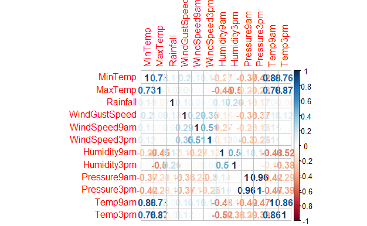

```r
numeric_vars_matrix <- as.matrix(weather_data1[, numeric_vars, drop=FALSE])
numeric_vars_cor <- cor(numeric_vars_matrix)
corrplot(numeric_vars_cor, method="number")
```

–> Converting categorical values from “Yes/No” to “0/1” to proceed with the further analysis on the data.

```r
library(plyr)

weather_data1$RainTomorrow <- revalue(weather_data1$RainTomorrow, c("Yes"=1))
weather_data1$RainTomorrow <- revalue(weather_data1$RainTomorrow, c("No"=0))

weather_data1$RainToday <- revalue(weather_data1$RainToday, c("Yes"=1))
weather_data1$RainToday <- revalue(weather_data1$RainToday, c("No"=0))

weather_data1
```

|  | MinTemp | MaxTemp | Rainfall | WindGustSpeed | WindSpeed9am | WindSpeed3pm | Humidity9am | Humidity3pm | Pressure9am | Pressure3pm | Temp9am | Temp3pm | RainToday | RainTomorrow |
| --- | --- | --- | --- | --- | --- | --- | --- | --- | --- | --- | --- | --- | --- | --- |
| 1 | 7.4 | 25.1 | 0.0 | 44 | 20 | 24 | 71 | 25 | 1007.7 | 1007.1 | 16.9 | 21.8 | 0 | 0 |
| 2 | 12.9 | 25.7 | 0.0 | 46 | 4 | 22 | 44 | 30 | 1010.6 | 1007.8 | 17.2 | 24.3 | 0 | 0 |
| 3 | 9.2 | 28.0 | 0.0 | 24 | 19 | 26 | 38 | 16 | 1007.6 | 1008.7 | 21.0 | 23.2 | 0 | 0 |
| 4 | 17.5 | 32.3 | 1.0 | 41 | 11 | 9 | 45 | 33 | 1017.6 | 1012.8 | 18.1 | 26.5 | 0 | 0 |
| 5 | 14.6 | 29.7 | 0.2 | 56 | 7 | 20 | 82 | 23 | 1010.8 | 1006.0 | 17.8 | 29.7 | 0 | 0 |
| 6 | 14.3 | 25.0 | 0.0 | 50 | 19 | 24 | 55 | 19 | 1009.2 | 1005.4 | 20.6 | 28.9 | 0 | 0 |
| 7 | 7.7 | 26.7 | 0.0 | 35 | 20 | 24 | 49 | 19 | 1009.6 | 1008.2 | 18.1 | 24.6 | 0 | 0 |
| 8 | 9.7 | 31.9 | 0.0 | 80 | 6 | 17 | 48 | 9 | 1013.4 | 1010.1 | 16.3 | 25.5 | 0 | 0 |
| 9 | 13.1 | 30.1 | 1.4 | 28 | 7 | 28 | 42 | 27 | 1008.9 | 1003.6 | 18.3 | 30.2 | 0 | 1 |
| 10 | 13.4 | 30.4 | 0.0 | 30 | 15 | 11 | 58 | 22 | 1007.0 | 1005.7 | 20.1 | 28.2 | 1 | 0 |

[output cut: 990 more lines]

–> We have plotted the histogram representation of the data against various attributes and observed that the data was normally distributed. Hence, any transformation of data was not necessarily required.

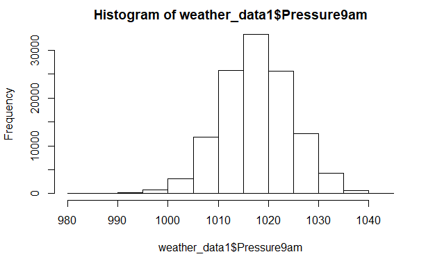

```r
hist(weather_data1$Pressure9am)
```

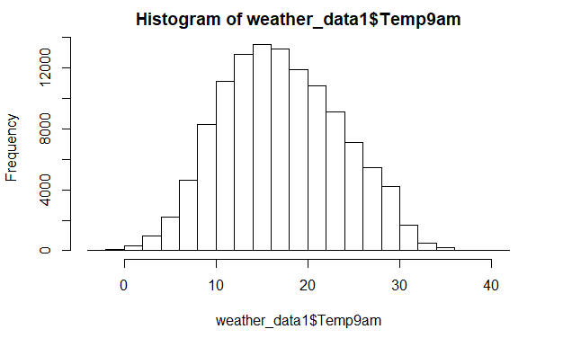

```r
hist(weather_data1$Temp9am)
```

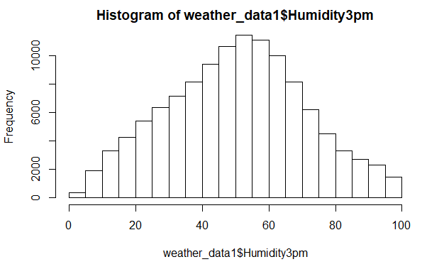

```r
hist(weather_data1$Humidity3pm)
```

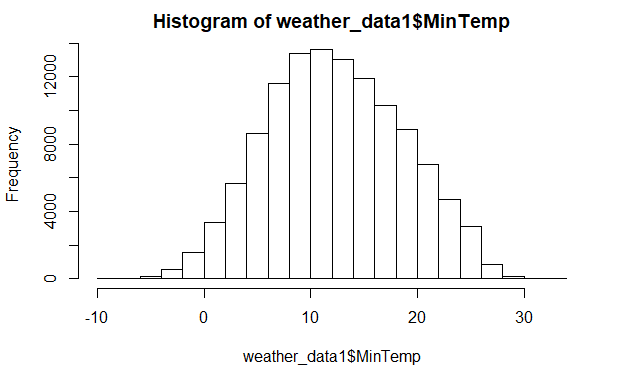

```r
hist(weather_data1$MinTemp)
```

### Splitting train and test data:

–> The data is splitted as training and test sets, split ratio for the training set was 75% and test set was 25%. we have used simple.split function for splitting operation.

```r
set.seed(123)
library(caTools)
split = sample.split(weather_data1$RainTomorrow, SplitRatio = 0.75)
training_set = subset(weather_data1, split == TRUE)
test_set = subset(weather_data1, split == FALSE)
View(training_set)
```

#### Methodology:

### LOGISTIC REGRESSION MODEL

–>Logistic Regression is used when the dependent variable(target) are categorical.

–>Here, the data related to weather information has categorical values i.e(Yes/NO), which was in return required to predict whether it will rain tomorrow. In our case, this dataset is very much suitable for applying Logistic regression.

Steps –> 1. First, we have trained the model with Training set data and printed the summary of the model. –> 2. Once the Model was trained,we used the test set data to predict the results for the $RainTomorrow –> 3. We have predicted the output for the test set data and their predicted results are shown below.

–> Confusion Matrix shows the Accuracy, precision and Kappa values.

### Modeling and Results:

–> Model training was performed using training set data.

```r
model <- glm ( RainTomorrow ~WindGustSpeed+Humidity3pm+Pressure3pm, data = training_set, family = binomial)
summary(model)
```

```
Call:
glm(formula = RainTomorrow ~ WindGustSpeed + Humidity3pm + Pressure3pm,
    family = binomial, data = training_set)

Deviance Residuals:
    Min       1Q   Median       3Q      Max
-2.5138  -0.6392  -0.3926  -0.1963   3.1194

Coefficients:
                Estimate Std. Error z value Pr(>|z|)
(Intercept)   80.2823302  1.4820195   54.17   <2e-16 ***
WindGustSpeed  0.0178512  0.0006998   25.51   <2e-16 ***
Humidity3pm    0.0559999  0.0005279  106.08   <2e-16 ***
Pressure3pm   -0.0842425  0.0014578  -57.79   <2e-16 ***
---
Signif. codes:  0 ‘***’ 0.001 ‘**’ 0.01 ‘*’ 0.05 ‘.’ 0.1 ‘ ’ 1

(Dispersion parameter for binomial family taken to be 1)

    Null deviance: 93169  on 88683  degrees of freedom
Residual deviance: 72877  on 88680  degrees of freedom
AIC: 72885

Number of Fisher Scoring iterations: 5
```

–>Using trained model, we have predicted the results on the Test data.

```r
prob_pred = predict(model, type = 'response', newdata = test_set[-14])
y_pred = ifelse(prob_pred > 0.5, 1, 0)
cm = table(test_set[, 14], y_pred>0.5)
print(cm)
```

```
    FALSE  TRUE
  0 21720  1376
  1  4401  2065
```

### Confusion matrix:

Accuracy: 80.46 Kappa: 0.3124

```r
confusionMatrix(factor(y_pred), factor(test_set$RainTomorrow),positive = "1")
```

```
Confusion Matrix and Statistics

          Reference
Prediction     0     1
         0 21720  4401
         1  1376  2065

               Accuracy : 0.8046
                 95% CI : (0.8, 0.8091)
    No Information Rate : 0.7813
    P-Value [Acc > NIR] : < 2.2e-16

                  Kappa : 0.3124

 Mcnemar's Test P-Value : < 2.2e-16

            Sensitivity : 0.31936
            Specificity : 0.94042
         Pos Pred Value : 0.60012
         Neg Pred Value : 0.83151
             Prevalence : 0.21873
         Detection Rate : 0.06985
   Detection Prevalence : 0.11640
      Balanced Accuracy : 0.62989

       'Positive' Class : 1
```

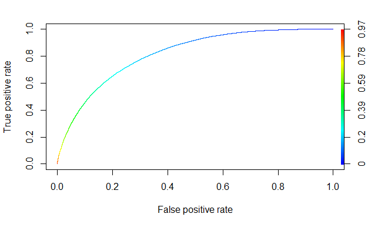

```r
predict <- predict(model, type = 'response')
tab<-table(training_set$RainTomorrow, predict > 0.5)

library(ROCR)
ROCRpred <- prediction(predict, training_set$RainTomorrow)
ROCRperf <- performance(ROCRpred, 'tpr','fpr')
plot(ROCRperf, colorize = TRUE, text.adj = c(-0.2,1.7))
```

```r
prediction(predict, training_set$RainTomorrow) %>%
  performance(measure = "auc") %>%
  .@y.values
```

```
[[1]]
[1] 0.8160764
```

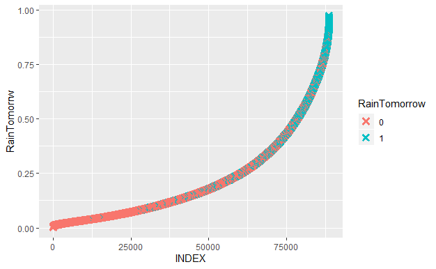

```r
predicted.data<-data.frame(probability.of.RainTomorrow=model$fitted.values,RainTomorrow=training_set$RainTomorrow)

predicted.data<-predicted.data[order(predicted.data$probability.of.RainTomorrow,decreasing=FALSE),]
predicted.data$rank<-1:nrow(predicted.data)

ggplot(data=predicted.data, aes(x=rank, y=probability.of.RainTomorrow))+
  geom_point(aes(colour=RainTomorrow),alpha=1, shape=4, stroke=2) + xlab("INDEX")+
  ylab("RainTomorrw")
```

### Model running for different variables for accuracy test:

```r
model1_linear <- glm ( RainTomorrow ~MinTemp+MaxTemp+WindSpeed9am+Humidity9am, data = training_set, family = binomial)
summary(model1_linear)
```

```
Call:
glm(formula = RainTomorrow ~ MinTemp + MaxTemp + WindSpeed9am +
    Humidity9am, family = binomial, data = training_set)

Deviance Residuals:
    Min       1Q   Median       3Q      Max
-2.0718  -0.6647  -0.3499  -0.0986   3.8385

Coefficients:
               Estimate Std. Error z value Pr(>|z|)
(Intercept)  -1.7576179  0.0752238  -23.36   <2e-16 ***
MinTemp       0.2640423  0.0028654   92.15   <2e-16 ***
MaxTemp      -0.2667282  0.0029400  -90.72   <2e-16 ***
WindSpeed9am  0.0285884  0.0010961   26.08   <2e-16 ***
Humidity9am   0.0359447  0.0006466   55.59   <2e-16 ***
---
Signif. codes:  0 ‘***’ 0.001 ‘**’ 0.01 ‘*’ 0.05 ‘.’ 0.1 ‘ ’ 1

(Dispersion parameter for binomial family taken to be 1)

    Null deviance: 93169  on 88683  degrees of freedom
Residual deviance: 71303  on 88679  degrees of freedom
AIC: 71313

Number of Fisher Scoring iterations: 6
```

Prediction on Test Dataset:

```r
prob_pred = predict(model1_linear, type = 'response', newdata = test_set[-14])
y_pred1 = ifelse(prob_pred > 0.5, 1, 0)
cm1 = table(test_set[, 14], y_pred1>0.5)
print(cm1)
```

```
    FALSE  TRUE
  0 21703  1393
  1  4235  2231
```

### Confusion Matrix:

Accuracy: 80.96 Kappa: 0.3382

```r
confusionMatrix(factor(y_pred1), factor(test_set$RainTomorrow),positive = "1")
```

```
Confusion Matrix and Statistics

          Reference
Prediction     0     1
         0 21703  4235
         1  1393  2231

               Accuracy : 0.8096
                 95% CI : (0.8051, 0.8141)
    No Information Rate : 0.7813
    P-Value [Acc > NIR] : < 2.2e-16

                  Kappa : 0.3382

 Mcnemar's Test P-Value : < 2.2e-16

            Sensitivity : 0.34504
            Specificity : 0.93969
         Pos Pred Value : 0.61562
         Neg Pred Value : 0.83673
             Prevalence : 0.21873
         Detection Rate : 0.07547
   Detection Prevalence : 0.12259
      Balanced Accuracy : 0.64236

       'Positive' Class : 1
```

### DECISION TREE MODEL

–> Decision Tree can handle both Categorical and Numerical Data. We have used the same Training and test data for the model training and prediction.

Below is the Decision Tree Model:

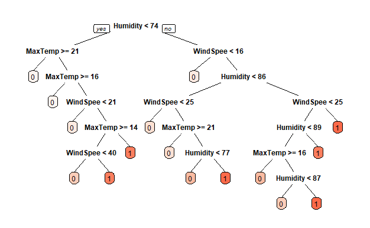

```r
Decisiontr <- trainControl(method = "repeatedcv", number = 10, repeats = 3)
decisiontree_fit <- train(RainTomorrow ~MaxTemp+Humidity9am+WindSpeed9am, data = training_set, method = "rpart",
                   parms = list(split = "information"),
                   trControl=Decisiontr,
                   tuneLength = 5)
prp(decisiontree_fit$finalModel, box.palette = "Reds", tweak = 1)
```

–> We are applying the trained model on the Test data and results are predicted.

Cunfusion Matrix: Accuracy: 79.3 Kappa: 0.1753

```r
predict(decisiontree_fit, newdata = test_set[1,])
```

```
[1] 0
Levels: 0 1
```

```r
test_pred <- predict(decisiontree_fit, newdata = test_set)
confusionMatrix(test_pred, test_set$RainTomorrow )
```

```
Confusion Matrix and Statistics

          Reference
Prediction     0     1
         0 22422  5445
         1   674  1021

               Accuracy : 0.793
                 95% CI : (0.7883, 0.7976)
    No Information Rate : 0.7813
    P-Value [Acc > NIR] : 4.648e-07

                  Kappa : 0.1753

 Mcnemar's Test P-Value : < 2.2e-16

            Sensitivity : 0.9708
            Specificity : 0.1579
         Pos Pred Value : 0.8046
         Neg Pred Value : 0.6024
             Prevalence : 0.7813
         Detection Rate : 0.7585
   Detection Prevalence : 0.9427
      Balanced Accuracy : 0.5644

       'Positive' Class : 0
```

### NAIVE BAYES MODEL:

–> Naive Bayes is an algorithm based on conditional probability and countng. It assumes that all the variables are contiditional independent.

–> The e1071 package in R has a built in Naive Bayee function that can compute the conditional probabilities of a independent predictor variables using Bayes rule.

–> We have used the same Training and test data for the model training and prediction.

```r
library(e1071)
naive_model <- naiveBayes(RainTomorrow ~MaxTemp+Humidity9am+WindSpeed9am, training_set)
naive_model
```

```
Naive Bayes Classifier for Discrete Predictors

Call:
naiveBayes.default(x = X, y = Y, laplace = laplace)

A-priori probabilities:
Y
        0         1
0.7812796 0.2187204

Conditional probabilities:
   MaxTemp
Y       [,1]     [,2]
  0 24.34963 6.951357
  1 20.42036 6.248148

   Humidity9am
Y       [,1]     [,2]
  0 65.64327 19.10901
  1 77.70263 16.09104

   WindSpeed9am
Y       [,1]     [,2]
  0 13.93397 8.535722
  1 15.89725 9.445773
```

–> Trained model was used on the Test data and results are predicted.

Cunfusion Matrix: Accuracy: 78.19 Kappa: 0.1602

```r
test_naive <- predict(naive_model, test_set)
confusionMatrix(test_naive, test_set$RainTomorrow )
```

```
Confusion Matrix and Statistics

          Reference
Prediction     0     1
         0 22031  5381
         1  1065  1085

               Accuracy : 0.7819
                 95% CI : (0.7772, 0.7866)
    No Information Rate : 0.7813
    P-Value [Acc > NIR] : 0.3924

                  Kappa : 0.1602

 Mcnemar's Test P-Value : <2e-16

            Sensitivity : 0.9539
            Specificity : 0.1678
         Pos Pred Value : 0.8037
         Neg Pred Value : 0.5047
             Prevalence : 0.7813
         Detection Rate : 0.7452
   Detection Prevalence : 0.9273
      Balanced Accuracy : 0.5608

       'Positive' Class : 0
```

### Comparision of models:

–> The modeling is performed on three models Logistic Regression, Decision Tree and Navie Bayes Models. The obtained results are as follows:

Logistic Regression:

Accuracy: 80.46 Kappa: 0.3124

Decision Tree:

Accuracy: 79.3 Kappa: 0.1753

Navie Bayes:

Accuracy: 78.19 Kappa: 0.1602

### Major Challenges:

–> 1.Dataset was in different formats and it has so much unwanted and improperly formatted data which has lot of NA values.

–> 2.Dataset cleaning was a time consuming and tricky task for our analysis.

### Results and Conclusion:

–> 2.Small number of observations predict that there will be rain tomorrow. Majority of observations predict that there will be no rain tomorrow.

–> 4. By observing the results from above models we could conclude that logistic regression gives best results whether it will rain tommorow or not.